# 20170719-Plot Application Rates

Anandini, Thoa

7/17/2019

Here we read in HSAPS data from 2009-10 to 2013-14. We only choose columns that has `r1programcode*` which specifies the program that a student ranks and applies to in the first round.

We also read June Biog data in to have info about 8th grade in 2009-10 to 2013-14.

## Sanity check:

Good news: students always fill out higher-ranked choices before lower-ranked ones. (That’s why the following code results in nothing)

```r
apps_0910_1314 %>%
  gather("choice", "program_applied", 3:14) %>%
  mutate(foo = is.na(program_applied)) %>%
  select(year, student_id_scram, choice, program_applied, foo) %>%
  arrange(year, student_id_scram) %>%
  group_by(year, student_id_scram) %>%
  summarize(bar = length(rle(foo)),
            baz = sum(lag(foo, default=0) != foo)) %>%
  filter(bar > 2 | baz > 1)
```

```
## # A tibble: 0 x 4
## # Groups:   year [0]
## # ... with 4 variables: year <dbl>, student_id_scram <chr>, bar <int>,
## #   baz <int>
```

## What percent of all 8th-grade applicants each school get in a year?

We need to calculate the total number of applicants per year, as follows. First table is from Method 1’s data. Second table is from Method 2’s data.

```
## # A tibble: 5 x 2
##    year total_applicants
##   <dbl>            <int>
## 1  2009            80082
## 2  2010            76810
## 3  2011            76424
## 4  2012            75505
## 5  2013            76624
```

```
## # A tibble: 5 x 2
##    year total_applicants
##   <dbl>            <int>
## 1  2009            64656
## 2  2010            64489
## 3  2011            70874
## 4  2012            70063
## 5  2013            71571
```

We first need to gather `r1programcode*` from wide to long, so each `student_id_scram` will have 12 rows of programcode (some rows will be NA if the student does not use all of the choices).

### If the program appears in one of the top 12 in 1st round.

### If the program appears in one of the top 6 in 1st round.

### If the program appears in one of the top 3 in 1st round.

### If the program appears in one of the top 1 in 1st round.

## Match program codes to school codes

### Read and clean up data:

We read in, merge and clean up the data that map programs (name & code) to schools (name & code).

- Note 1: from OpenData NYC, we are able to obtain data of three years: 2016, 2014-15, 2013-14.
- Note 2: we read in two types of tables. One maps program codes to dbn’s. The other maps dbn’s to school names.

Then we do some sanity check, as follows:

```r
# this code helps us find out that programs offered at the 9 specialized schools do not have codes.
allschoolcodes %>%
  filter(is.na(pgcode) | pgcode == "NO CODE")
```

```
## # A tibble: 42 x 7
##      year pgcode                           pgname    dbn
##     <dbl>  <chr>                            <chr>  <chr>
##  1 201314   <NA> The Bronx High School of Science 10X445
##  2 201314   <NA>                         Fine Art 03M485
##  3 201314   <NA>                            Dance 03M485
##  4 201314   <NA>               Instrumental Music 03M485
##  5 201314   <NA>                      Vocal Music 03M485
##  6 201314   <NA>                            Drama 03M485
##  7 201314   <NA>                Technical Theatre 03M485
##  8 201314   <NA>                      Engineering 31R605
##  9 201314   <NA>                       Stuyvesant 02M475
## 10 201314   <NA>                  Pre-Engineering 05M692
## # ... with 32 more rows, and 3 more variables: school_name <chr>,
## #   interest <chr>, method <chr>
```

```r
# because there are no program codes there, we will drop these schools from our table.
# MANUAL WAY:
# allschoolcodes <-
#   allschoolcodes %>%
#   filter(!(dbn %in% c("03M485",
#                       "10X445",
#                       "31R605",
#                       "02M475",
#                       "05M692",
#                       "10X696",
#                       "13K430",
#                       "14K449",
#                       "28Q687")))
# SMARTER WAY:
allschoolcodes <-
  allschoolcodes %>%
  filter(!is.na(pgcode) & pgcode != "NO CODE")

# now every program appears only once per school in each year.
allschoolcodes %>%
  group_by(pgcode, dbn, year) %>%
  count() %>%
  filter(n != 1)
```

```
## # A tibble: 0 x 4
## # Groups:   pgcode, dbn, year [0]
## # ... with 4 variables: pgcode <chr>, dbn <chr>, year <dbl>, n <int>
```

```r
# even more precise: each program is unique to each school
allschoolcodes %>%
  group_by(pgcode) %>%
  summarize(num_schools = length(unique(dbn))) %>%
  filter(num_schools != 1)
```

```
## # A tibble: 0 x 2
## # ... with 2 variables: pgcode <chr>, num_schools <int>
```

```r
# but one school may have multiple programs
allschoolcodes %>%
  group_by(dbn) %>%
  summarize(num_programs = length(unique(pgcode))) %>%
  filter(num_programs != 1)
```

```
## # A tibble: 122 x 2
##       dbn num_programs
##     <chr>        <int>
##  1 01M448            3
##  2 02M374            3
##  3 02M400            2
##  4 02M408            4
##  5 02M420            2
##  6 02M425            2
##  7 02M519            5
##  8 02M520            2
##  9 02M533            2
## 10 02M542            4
## # ... with 112 more rows
```

## What are some of the most “popular” HS in each year?

Our initial definition of popularity is the highest percentages of applicants a school receives in a year. Later on, we want to incorporate the number of seat availability and calculate the ratio of num_apps : seats_avail. The higher this ratio is, the more popular a school is.

Since there are too many tables and graphs, for now, we will use data obtained from Method 1 above.

Note: when we did the mapping of programs to schools, there were 574 program codes in 2009 to 2013 that do not match to any school dbn.

The following code selects out the top 10 most popular school in EACH year:

```r
school_apprates <-
  top12_apps_and_schools_method1 %>%
  filter(!is.na(dbn)) %>%
  group_by(year, dbn, school_name) %>%
  summarize(num_applications = sum(num_applications),
            total_applicants = mean(total_applicants),
            app_rate = num_applications/total_applicants) %>%
  arrange(year, desc(app_rate)) %>%
  group_by(year) %>%
  top_n(10)
```

## Plot % applicants to different programs

### Top 10 schools in each year

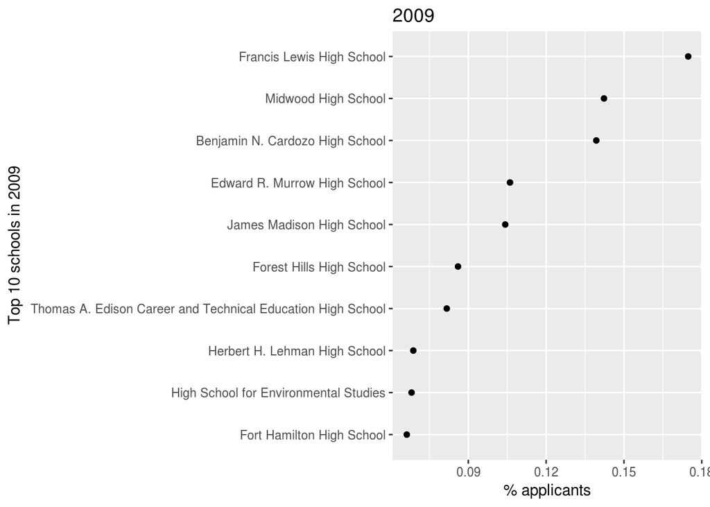

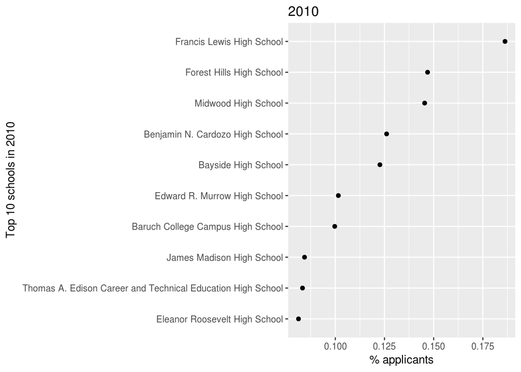

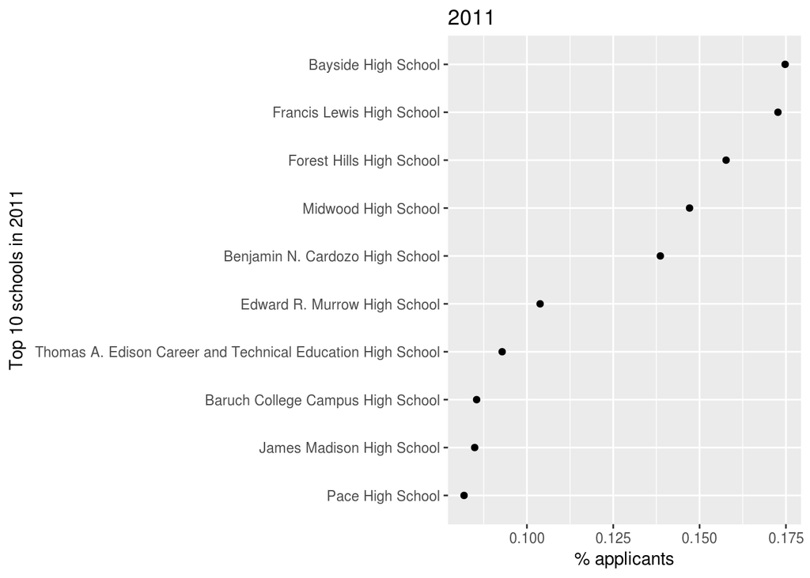

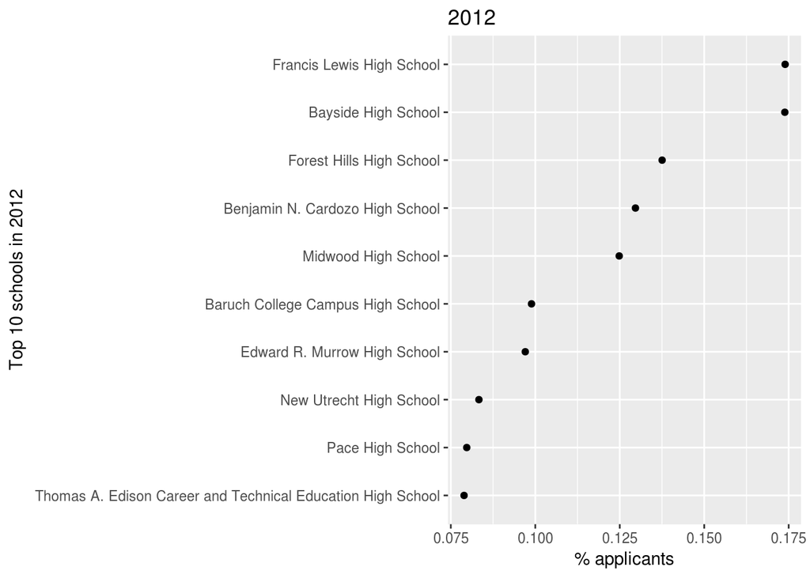

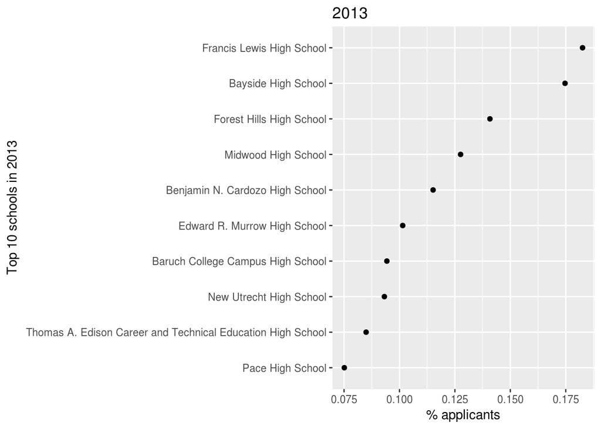

### Comparing the % applicants of different schools

Schools here are ranked based on a metric we named “aggregate app rate” which is the ratio of:

- numerator: summing across all years the num_applicants each school receives each year
- denominator: summing across all years the total_applicants each year

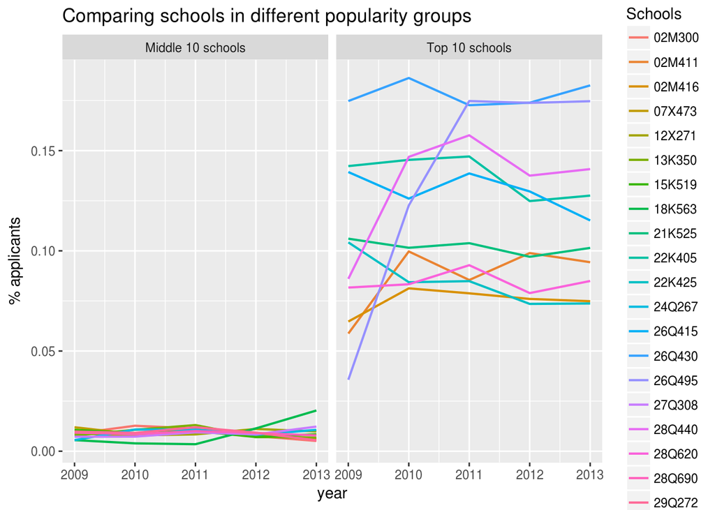

### Distribution of % applicants

- Top N: an applicant lists a program anywhere in the top N of their choice list.
- Method 1 selects the first year each applicant appears in the HSAPS data. It runs the risk of missing out applicants who might have applied for 9th grade in more than one year, e.g. because they were held back in 8th grade.
- Method 2 selects applicants that are listed in June Biog as 8th-grader in the year they applied. The risk is that June Biog data might repeat entries for some 8th-graders although they were not necessarily held back.

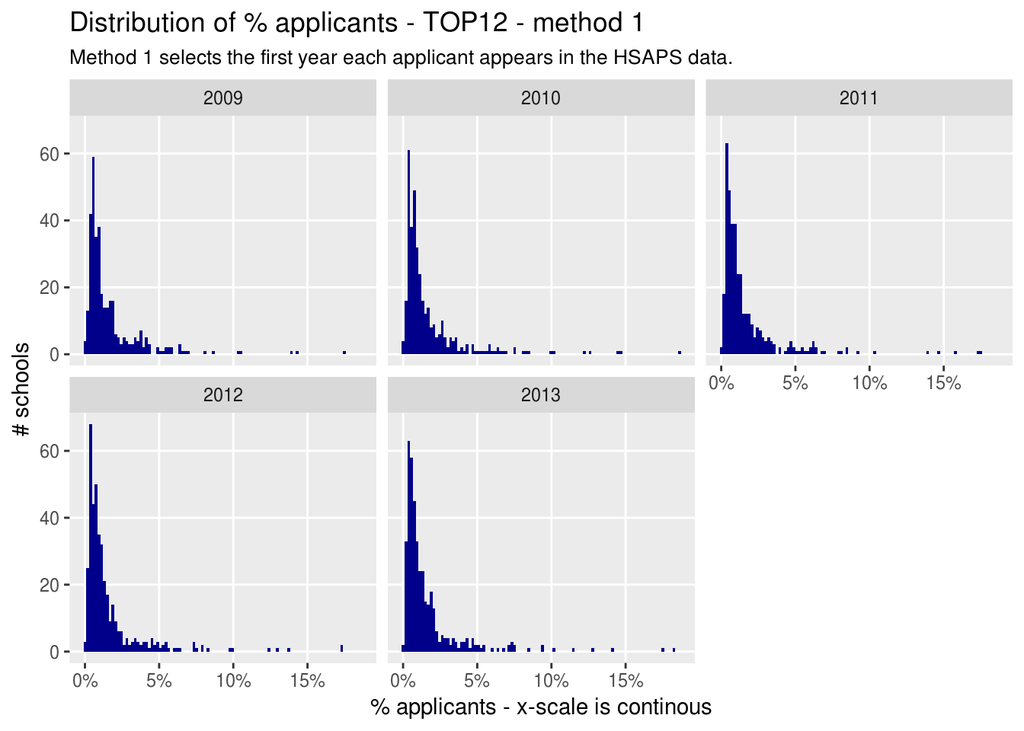

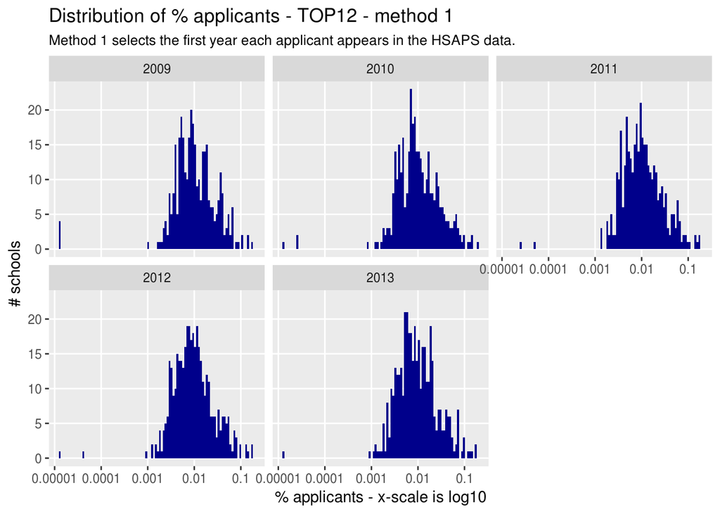

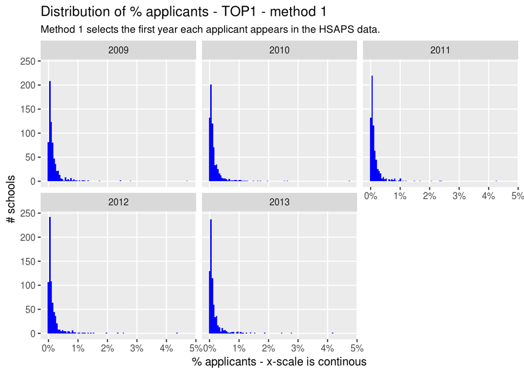

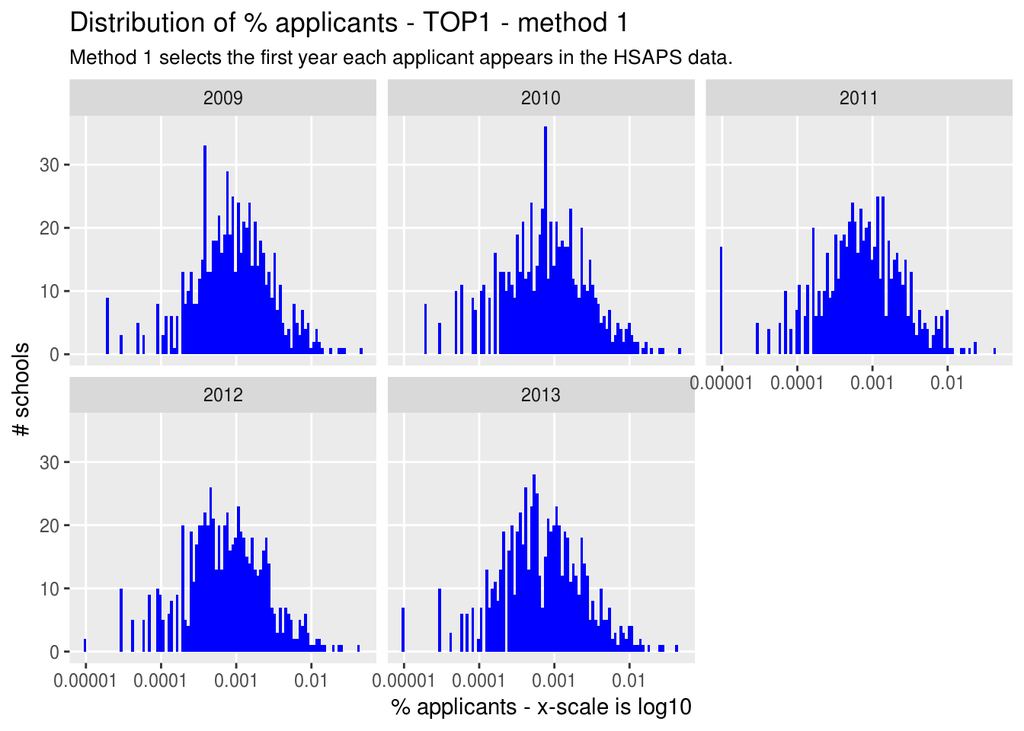